# Adrien Website - Avant-propos

Author

Affiliation

Adrien Fillon

[ERA chair in Science and Innovation Policy & Studies](https://www.ucy.ac.cy/sinnopsis/)

Published

July 3, 2023

# Introduction

Cette série d’article ne s’adresse ni à des statisticiens, ni à des mathématiciens. Elle s’adresse aux chercheurs et au grand public qui souhaitent s’informer sur le fonctionnement des méta-analyses, apprendre à les lire et à en intérpreter les résultats.

A ce propos, je m’appuierai essentiellement sur les guides de (Harrer 2022) et (Viechtbauer 2010), disponibles gratuitement en anglais et qui vous permettrons de réaliser vos propres méta-analyses avec R (et beaucoup de temps et de pugnacité).

# Le contexte de la méta-analyse

La science quantitative se compose de deux domaines. La première est la collecte de résultats, qui est faite à travers des études individuelles. La seconde est la synthèse de ces résultats, qui est faite à travers des revues systématiques et des… méta-analyses.

En 1976, Glass utilise pour la première fois le terme “méta-analyse” pour parler de l’intégration de données individuelles. Depuis les années 90, le nombre de méta-analyses augmente de manière exponentielle. Une étude publiée dans *Science* (Jop de Vrieze 2018) en 2017 le montre clairement. De plus, un tier des méta-analyses sont publiées en Chine.

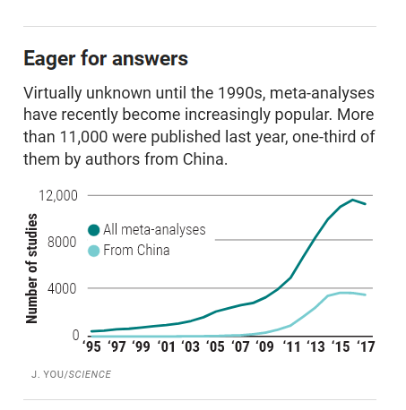

.

Bref, la méta-analyse a la cote. Ce n’est pas pour rien : il y a un réel besoin de synthétiser les résultats de recherches afin de savoir ce que chacun fait tout autour du monde, de savoir si nous allons dans la bonne direction et si ce que l’on étudie a un sens, et une utilité. Il est aussi important de pouvoir fournir des recommandations à la population en fonction des niveaux de preuves que nous avons.

Cependant, les résultats d’une méta-analyse dépendent essentiellement de choix des chercheurs dans la méta-analyse, raison pour laquelle il est capital de s’assurer que la méta-analyse a été faite dans de bonnes conditions.

Pourtant, en psychologie, les voyants sont au rouge. En 2020, une analyse (Leclercq et al. 2020) de 206 méta-analyses publiées dans PsychINFO indiquait les résultats suivants:

> Selon les critères AMSTAR2, 95 % des 206 méta-analyses ont été jugées de qualité critiquement faible. Les méthodes statistiques étaient appropriées et le biais de publication a été bien évalué dans 87 % et 70 % des méta-analyses, respectivement. Toutefois, la collecte et l’analyse des données doivent être considérablement améliorées : seules 11 % des méta-analyses ont publié un protocole de recherche, 44 % avaient une stratégie de recherche documentaire complète, 37 % ont évalué et 29 % ont interprété le risque de biais dans les études individuelles incluses, et 11 % ont présenté une liste d’études exclues.

La même années, une seconde étude (Hohn, Slaney, and Tafreshi 2020) sur 384 méta-analyses concluait:

> Nos résultats suggèrent que (a) plusieurs pratiques de recherche menées par les méta-analystes ne sont finalement pas rapportées ; (b) certains aspects de la recherche en méta-analyse semblent être menés à des taux décevants ; et (c) l’adoption des normes de rapport, y compris les normes de rapport méta-analytique (MARS), a été lente ou inexistante au sein de la recherche en méta-analyse en psychologie.

En économie, la situation n’est guère plus enviable (Stanley and Doucouliagos 2019)

> Dans les conditions courantes de la recherche en économie, ces méthodes [utilisées en méta-analyse] présentent trop souvent des taux d’erreurs de type I inacceptables. Les biais et les taux de faux positifs de toutes les méthodes simples de méta-analyse s’aggravent considérablement en cas de forte hétérogénéité. Malheureusement, les niveaux typiques d’hétérogénéité observés dans les résultats de la recherche en économie sont suffisants pour rend presque toutes les méta-analyses problématique, si elles ne sont pas interprétées avec beaucoup de soin ou testée par rapport à sa signification pratique.

En médecine non plus (Hameed et al. 2020)

> Cette étude soulève des préoccupations concernant la qualité des rapports et de la méthodologie des méta-analyses publiées dans des revues à fort impact La participation précoce de spécialistes de l’information, la stipulation de directives détaillées pour les auteurs et le strict respect de celles-ci peuvent améliorer la qualité des méta-analyses publiées.

Cochrane, nous le verrons dans la partie sur les biais de publication, est une organisation proposant des méta-analyses sur les interventions dans le domaine de la santé, dont voici un résumé (Howick et al. 2022)

> Sur les 1 567 interventions éligibles [les méta-analyses publiées par Cochrane], 87 (5,6 %) ont fait l’objet de preuves de haute qualité quant à leurs bénéfices. Les effets néfastes ont été mesurés pour 577 (36,8 %) interventions. Pour 127 d’entre elles (8,1 %), des preuves statistiquement significatives d’effets néfastes ont été apportées. […] Plus de 9 interventions de soins de santé sur 10 étudiées dans le cadre de revues Cochrane récentes ne sont pas étayées par des preuves de haute qualité et les préjudices ne sont pas suffisamment signalés.

Bref, il y a du boulot pour relever le niveau de qualité des méta-analyses.

# Une petite définition

La méta-analyse est, selon Glass (1976) une “analyse d’analyses” ce qui nous donne une information capitale : le niveau d’analyse des méta-analyse n’est pas les individus, les espèces, les comportements… mais les études publiées sur ces individus ou autres.

De manière générale, la synthèse de preuve se découpe en trois catégories

- **La revue narrative** qui a pour objectif, pour un chercheur ou un expert sur un sujet d’expliquer ce qu’il sait du sujet
- **La revue systématique** qui a pour objectif de faire le tour d’un sujet de manière systématique, en collectant tous les articles sur le sujet avec un guide rigoureux et transparent. L’objectif est de s’assurer d’avoir collecté toutes les données sur le sujet pour en faire la synthèse, grâce à un protocole systématique.
- **La méta-analyse** qui peut être vue comme la suite de la revue systématique, à laquelle est ajoute une analyse statistique. Ainsi, certains articles s’appellent explicitement “revue systématique et méta-analyse sur ce sujet”. L’objectif d’une méta-analyse est de parvenir à une intégration quantitative des données en une donnée numérique.

# Et un petit historique

Depuis, de nombreux chercheurs ont amélioré la technique de méta-analyse. Citons en premier le livre “introduction à la méta-analyse” (Borenstein et al. 2021). Schmidt and Hunter (2015) qui ont développé une méthode alternative à la méta-analyse, et enfin [Cochrane](https://www.cochrane.org/).

[Cochrane](https://www.cochrane.org/) est un réseau international de chercheurs, de professionnels, de patients et d’autres acteurs qui “travaillent ensemble pour produire des informations crédibles et accessibles sur la santé, sans parrainage commercial ni autres conflits d’intérêts”. Cochrane utilise des normes rigoureuses pour synthétiser les données dans le domaine biomédical.

La Collaboration Cochrane produit le Handbook for Systematic Reviews of Interventions, régulièrement mis à jour, et le Cochrane Risk of Bias Tool. Tous deux sont largement considérés comme des ouvrages de référence standard pour tous les détails techniques sur les revues systématiques et les méta-analyses. Bref, une référence.

# Ce qu’il vous faut pour faire une méta-analyse

D’un point de vue matériel, il ne faut presque rien pour faire une méta-analyse : un éditeur de texte, à tout hasard *word*, un aggrégateur d’études, à tout hasard *Zotero*, et un logiciel d’analyse, à tout hasard *R* et *Rstudio*. Voilà. Non vraiment, tout le monde a les moyens de faire une méta-analyse. Ce qui est plus difficile à obtenir, en revanche, c’est… le temps. Une méta-analyse c’est très long. Prenez le temps que vous estimez mettre pour la faire, et multipliez la par trois, au minimum. Pour un **groupe** d’experts, une méta-analyse mets *en moyenne* 8 mois. Pour un individu seul avec seulement quelques livres (dont ce présent guide), comptez deux à trois ans entre l’élaboration de la question et la soumission à publication. Plusieurs doctorants me contactent en me proposant de les aider à faire une méta-analyse durant leur dernière année de doctorant. Je vous réponds sérieusement : vous n’aurez pas le temps. Mais comment il se découpe, ce temps ? Prenons l’exemple du chercheur seul, ou en petit groupe.

- élaboration de la question : deux semaines
- Rédaction de l’introduction : deux semaines
- Rédaction et élaboration du protocole de recherche systématique : 1 mois
- Envoi de l’étude en stage 1 : entre 1 et 3 mois (mais au moins on a du temps pour faire autre chose)
- Récolte des études et codage : 4 à 6 mois
- Analyse et rédaction des résultats : 2 semaines
- Discussion et finalisation du manuscript : 2 semaine
- relecture (toi même tu sais, les deadlines des professeurs) : 1 mois

On a donc dans un monde idéal, un strict minimum de 9 mois, et un maximum de 13 mois. 13 mois, c’est le temps qu’il m’a fallu pour ma première méta-analyse, en étant moi-même aidé d’un expert pour la partie technique. Je pense qu’il est raisonnable de penser que c’est le minimum pour une équipe avec une expérience limitée de la méta-analyse. Vous voilà prévenu.

# Les problèmes récurrents associés aux méta-analyses et quelques solutions

## La pomme et l’orange

Nous le répèterons tous au long des prochains chapitres, un des moments critiques de la méta-analyse est le moment de se poser la question de recherche, amenant aux critères d’inclusions et d’exclusion. Quand on s’intéresse à un effet particulier, il n’est pas rare d’hésiter entre inclure certaines recherches qui ressemblent à notre question, mais pas tout à fait.

> Dans une méta-analyse, nous souhaitions savoir si le statut socio-économique pouvait être manipulé (est ce qu’on pouvait, même momentanément, amener quelqu’un à se sentir plus haut dans la hiérarchie sociale, ou plus bas). Généralement, les chercheurs utilisent une échelle et indiquent aux participants où ils se trouvent sur cette échelle, en indiquant qu’ils se trouvent plus haut ou plus bas qu’ils ne le sont réellement. Mais certains chercheurs font jouer les participants à des jeux de plateau - devions nous les exclure sur la base que ce n’est pas leur status socio-économique réel qui est manipulé ? Parfois on leur demandait de se comparer à leurs pairs - devions nous les exclure car la comparaison n’est pas la société générale ? Parfois on leur proposaient de se projetter dans un futur ou ils seraient beaucoup plus riches ou pauvres - devions nous les exclure parce que n’est dans un univers alternatif ? (Notre réponse à été oui pour les trois).

**Solutions** En premier, il est nécessaire d’avoir une bonne vue d’ensemble avant d’éffectuer la revue systématique. Pour cela, on peut lire d’anciennes revues systématiques sur le sujet, pourquoi pas des revues narratives, et ne pas hésiter à poser des questions aux experts dans ce domaine. Contacter deux à trois chercheurs en leur indiquant notre question de recherche pour leur demander leur avis est une bonne pratique pour s’éviter des ennuis par la suite. Une fois la question posée, il est important de correctement fixer à l’avance des critères stricts d’inclusion et d’exclusion, afin de ne plus revenir dessus.

L’objectif étant toujours d’avoir suffisamment d’études pour répondre à notre question, mais que les effets de ces études soient suffisament semblables pour être comparables.

## Gargabe in, garbage out

Beaucoup plus problématique et difficile à résoudre, le problème du “les déchets qui entrent font des déchets qui sortent” (c’est vraiment une traduction nulle). Le résultat d’une méta-analyse dépend de deux facteurs : les études inclues et les décisions prises par le méta-analyste. Ainsi, si **au moins une** étude inclue dans une méta-analyse est problématique, une fraude ou issue de pratiques de recherches questionnables, alors les résultats de la méta-analyse ne seront pas fiables.

## File Drawer Problem

Ce problème se réfère aux études et résultats que les chercheurs n’ont pas publié, pour différentes raisons (les résultats n’étaient pas positifs, les doctorants n’ayant pas continué dans le milieu académique, l’oubli). Malheureusement, la difficulté à publier des études ne supportant pas l’hypothèse d’un effet est courant. Ainsi, si on ne collecte pour la méta-analyse que les études publiées, on risque d’être victime d’un biais de positivité.

## Degré de liberté du méta-analyste

Durant la méta-analyse, le chercheur va devoir faire des choix à de nombreuses reprises. Pour étudier un même effet, deux méta-analyses peuvent aboutir à des résultats totalement différents.

## References

Borenstein, M., L. Hedges, V. Higgins, and J. P. T. and Rothstein. 2021. *Introduction to Meta-Analysis, 2nd Edition*. https://www.wiley.com/en-us/Introduction+to+Meta+Analysis%2C+2nd+Edition-p-9781119558354.

Boseley, Sarah. 2019. “Work of Renowned UK Psychologist Hans Eysenck Ruled ‘Unsafe’.” *The Guardian*, October. https://www.theguardian.com/science/2019/oct/11/work-of-renowned-uk-psychologist-hans-eysenck-ruled-unsafe.

Glass, GENE V. 1976. “Primary, Secondary, and Meta-Analysis of Research.” *Educational Researcher* 5 (10): 3–8. https://doi.org/10.3102/0013189X005010003.

Hameed, Irbaz, Michelle Demetres, Derrick Y. Tam, Mohamed Rahouma, Faiza M. Khan, Drew N. Wright, Keith Mages, et al. 2020. “An Assessment of the Quality of Current Clinical Meta-Analyses.” *BMC Medical Research Methodology* 20 (1): 105. https://doi.org/10.1186/s12874-020-00999-9.

Harrer, Mathias. 2022. *Doing Meta-Analysis with R: A Hands-on Guide*. First edition. Boca Raton: CRC Press.

Hohn, Richard E., Kathleen L. Slaney, and Donna Tafreshi. 2020. “An Empirical Review of Research and Reporting Practices in Psychological Meta-Analyses.” *Review of General Psychology* 24 (3): 195–209. https://doi.org/10.1177/1089268020918844.

Howick, Jeremy, Despina Koletsi, John P. A. Ioannidis, Claire Madigan, Nikolaos Pandis, Martin Loef, Harald Walach, et al. 2022. “Most Healthcare Interventions Tested in Cochrane Reviews Are Not Effective According to High Quality Evidence: A Systematic Review and Meta-Analysis.” *Journal of Clinical Epidemiology* 148 (August): 160–69. https://doi.org/10.1016/j.jclinepi.2022.04.017.

Jop de Vrieze. 2018. “Meta-Analyses Were Supposed to End Scientific Debates. Often, They Only Cause More Controversy.” *Science*. https://www.science.org/content/article/meta-analyses-were-supposed-end-scientific-debates-often-they-only-cause-more.

Leclercq, Victoria, Charlotte Beaudart, Sara Ajamieh, Ezio Tirelli, and Olivier Bruyère. 2020. “Methodological Quality of Meta-Analyses Indexed in PsycINFO: Leads for Enhancements: A Meta-Epidemiological Study.” *BMJ Open* 10 (8): e036349. https://doi.org/10.1136/bmjopen-2019-036349.

Schmidt, Frank L., and John E. Hunter. 2015. *Methods of Meta-Analysis: Correcting Error and Bias in Research Findings*. 1 Oliver’s Yard, 55 City Road London EC1Y 1SP: SAGE Publications, Ltd. https://doi.org/10.4135/9781483398105.

Stanley, T. D., and Hristos Doucouliagos. 2019. “Practical Significance, Meta-Analysis and the Credibility of Economics.” {SSRN} {Scholarly} {Paper}. Rochester, NY. https://doi.org/10.2139/ssrn.3427595.

Viechtbauer, Wolfgang. 2010. “Conducting Meta-Analyses in R with the Metafor Package.” *Journal of Statistical Software* 36 (3): 1–48. https://doi.org/10.18637/jss.v036.i03.

## Citation

BibTeX citation:

```
@online{fillon2023,
  author = {Adrien Fillon},
  title = {Avant-Propos},
  date = {2023-07-03},
  langid = {en}
}
```

For attribution, please cite this work as:

Adrien Fillon. 2023. “Avant-Propos.” July 3, 2023.